# Prediction and interpretation

Forrest W. Crawford

# Prediction

We have talked about fitting models to data, making their output and dynamics match what we observe empirically in the real world.

But models are most useful, *and most dangerous*, when we use them to generalize about circumstances we have not yet seen.

This could mean a different time, a different population, different interventions, or different parameter inputs.

## Running models forward

Suppose you have parameterized a model $y(t|\theta)$ with parameters $\theta$ and calibrated it to some time range $[0,T]$. This allows you to “run” the model to get values for $y(t|\theta)$ for $[0,T]$. If these match your data, then you are doing well!

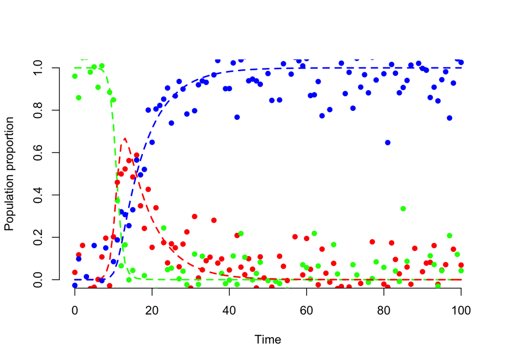

## Out-of-sample prediction

A model that fits data well is nice, but you might wish to:

- Predict $y(t|\theta)$ for $t>T$. Example: forecast next year’s influenza incidence, based on historical data.
- Predict $y(t|\theta)$ when you change $\theta$. Example: What would happen if the treatment were twice as effective?
- Predict $y(t|\theta)$ when you change the structure of the model, but keep $\theta$ the same. Example: What if there is a latent period following infection, but transmission remains the same?

## Example: vaccination policy

Suppose we implement a policy vaccinating all newborn babies against a disease. We see disease incidence over the following year. How does this compare to *what would have occurred, had the vaccination program not been implemented*?

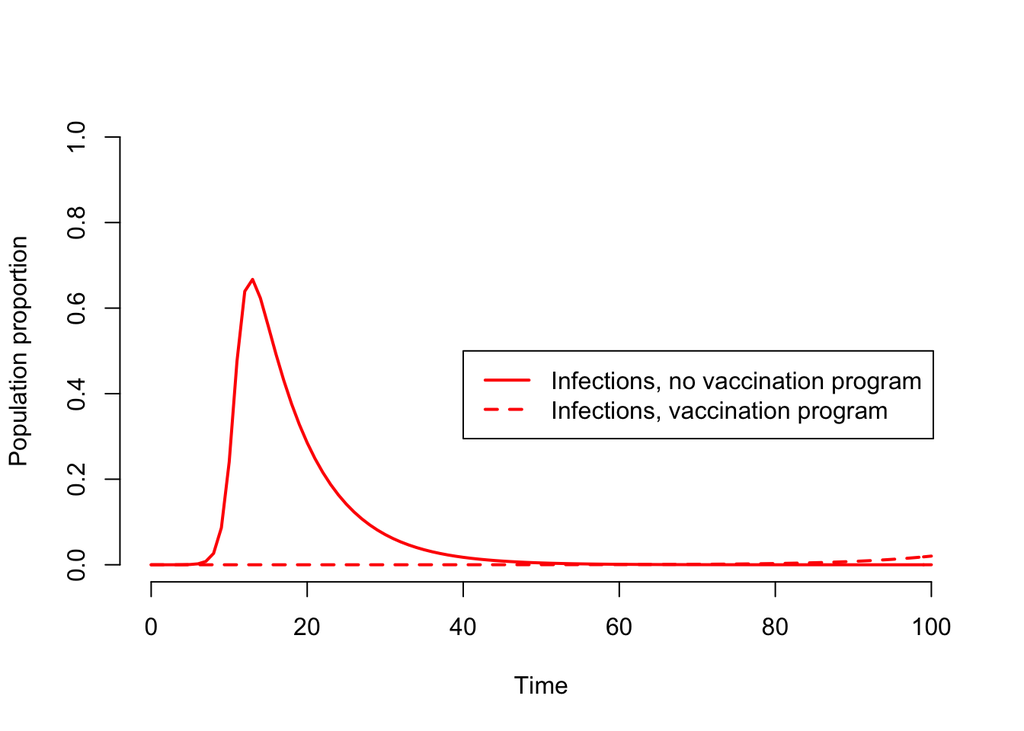

# Sensitivity analysis

## What is sensitivity analysis?

*Sensitivity analysis* is the process of learning about how your model output depends on its input parameters.

- Sensitivity to initial conditions
- Sensitivity to parameter values
- Sensitivity to intervention effects

## Example: sensitivity to compartment starting values

$\tilde{S}(0) \sim \text{Uniform}(0,1)$, $\tilde{I}(0) = 1-\tilde{S}(0)$, $\tilde{R}(0)=0$

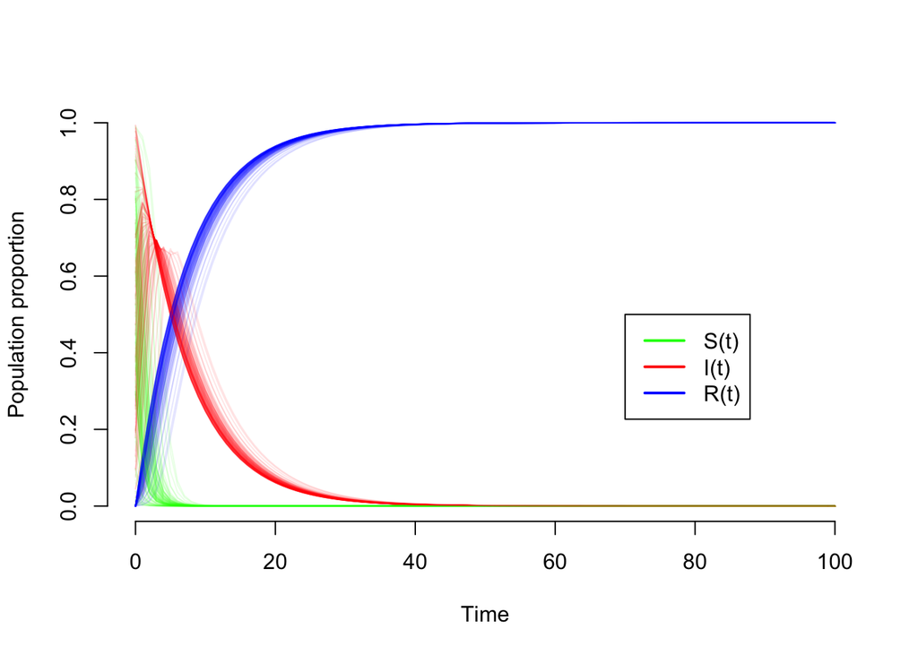

## Example: sensitivity to parameter values

$\tilde\beta \sim \text{Normal}(\beta,0.03)$, $\tilde\gamma \sim \text{Normal}(\gamma,0.03)$

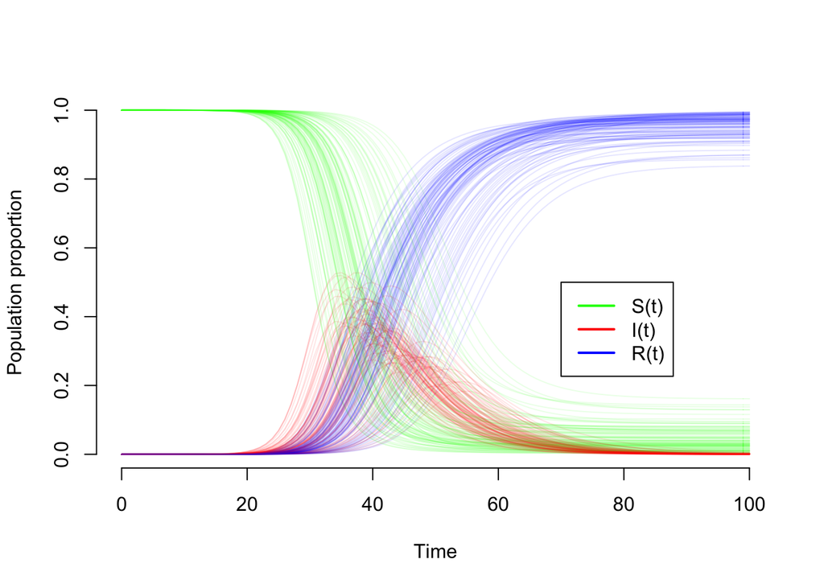

# Interpretation of evidence from models

## When are predictions “causal”?

Causal inference is a major area of active study in philosophy, epidemiology, economics, and statistics. All scientists want to know about the effect of treatments, or changes to the structure of a mechanism.

A critical part of causal inference is reasoning about *potential* or *counterfactual* outcomes. That is, what might have happened, had circumstances been different.

Example: Your doctor gives you an anti-hypertensive drug to treat your high blood pressure. You go the next year without any health issues. How does this outcome compare to *what would have occurred, had you not received the drug*?

Modeling can help us answer these questions, because models can “fill in” unobserved counterfactual outcomes.

## When are predictions not “causal”?

The problem is that we might be wrong, by a little or a lot, about the mechanism (model) by which the outcome of interest is generated. If we are wrong about the mechanism, we may be wrong about our *counterfactual* outcome. And we may erroneously conclude that a helpful intervention is harmful, or vice versa.

## What we need from models

Ultimately modeling is primarily a rhetorical task – the purpose is to explain and convince people to pursue a particular course of action.

We already know that models do not capture the rich structure of the real world. What we need from evidence generated by modeling is *credibility*, which comes from our argument that we have captured the salient features of the process of interest. A model does not have to be perfect to be useful.

Good models capture a mechanism of interest and give operational insight, *endowing their predictions with a causal interpretation*.

## Why worry about credibility

One of the keys to being a good modeler is to be skeptical of models in general. All models are gross simplifications of reality.

But we don’t always know whether a model is good, because we don’t observe counterfactual outcomes. Charles Manski’s law of decreasing credibility gives a heuristic about model complexity:

> The credibility of inference decreases with the strength of assumptions maintained.

By Manski’s standard, most of the models outlined in this course are not credible: they make strong assumptions that may be unverifiable.

See: Manski (2009), Manski (2013)

## Credibility and complexity: a compromise

Manski is right. We should be skeptical of complex models that purport to capture all relevant features of a complex process.

But sometimes a little mechanistic insight goes a long way. Empirical evidence of this is all around us. Somehow, we make good decisions in public health (and other human affairs) with incomplete information. Simple rules and heuristics are useful.

Our vision of modeling is as an iterative process of specifying a model that is too complex, then scaling it back to be as simple as possible, but no simpler.

## References

Manski, Charles F. 2009. *Identification for Prediction and Decision*. Harvard University Press.

———. 2013. *Public Policy in an Uncertain World: Analysis and Decisions*. Harvard University Press.